# DEA accredited projects analysis 2019-2025

## Strategic context

The UK government has begun positioning high-quality data as critical national infrastructure, investing over £100 million in the ADR UK program alone since 2018. The Digital Economy Act 2017 (DEA) has created unprecedented opportunities for streamlined access to survey and large-scale, linked public administrative datasets for research in the public good. As this data becomes increasingly important for evidence-based policymaking, particularly to address complex and cross-cutting challenges like productivity gaps and social and health inequalities, understanding how this investment translates into impact is crucial.

Public funders need evidence that national datasets deliver research impact that justifies their development and maintenance costs, and help identify where future resources should be concentrated to support their use. Simultaneously, tracking the evolution of research themes provides early intelligence on emerging policy challenges and scientific opportunities, ensuring infrastructure keeps pace with researcher demand. With research access requests under the DEA steadily increasing (and likely to accelerate in future, given growth in the availability of valuable large-scale linked administrative data that programmes like ADR UK are driving forward), understanding demand trajectories is critical for capacity planning, from project approval pipelines to the secure environments that support data access, so that infrastructure does not become a bottleneck to the very research it was designed to support.

## Aims of the project

This analysis aims to help understand how publicly-funded data infrastructure is supporting public policy research, what the relative demand for different sensitive datasets is, and how research interests using this data have evolved over time.

### Part 1: Quantifying dataset usage in DEA-accredited research

- Measure how many research projects have been approved under the DEA since the public register of projects began (Q4 2019).
- Track which datasets have been requested most often to identify demand patterns across all available data resources.
- Assess the uptake and growth of ADR UK flagship datasets specifically. These are large-scale, linked administrative datasets representing significant public investment and research value. This analysis focuses on [ADR England flagship datasets](https://www.adruk.org/data-access/flagship-datasets/?tx_llcatalog_pi%5Bfilters%5D%5Bpartners%5D=766&cHash=352fa45e86742c514f344c3d0b418a73) (as flagship datasets from other ADR UK partners from the devolved administration are largely not present in the public register dataset), examining both overall usage trends and patterns within individual collections.

### Part 2: Understanding shifts in research focus over time

- Use text analysis of project titles to identify dominant themes in research.
- Track emerging and declining research topics using frequency and TF-IDF metrics to understand how research priorities evolve.
- Provide visual summaries to show how topic focus has changed over time, revealing trends in policy research interests.

## Approach:

### Part 1: Dataset access trends

(All code available on [github](https://github.com/balintstewart77/ADR_DEA_project)), main project notebook [here](https://github.com/balintstewart77/ADR_DEA_project/blob/main/analysis/DEA_projects_analysis.ipynb)

- Scraped and cleaned public data on all research projects approved under the DEA from 2019 (when records in the public register began) onward: UK Statistics Authority website
- Filtered to exclude projects under a different legal gateway (SRSA 2007 - a gateway limited to research for purely statistical purposes) to ensure a focus on Digital Economy Act approved-research.
- Categorised datasets and grouped some into collections (e.g., “Data First” and “Wage and Employment Dynamics”) for clarity.
- Visualised the growth in use of ADR UK flagship datasets as a whole and split by collection, quarter by quarter.
- Calculated compounded growth rates for these.
- Created summary tables and visualisations showing trends and growth over time, which can be easily copied into reports.

### Part 2: Topic trends in research

- Analysed the titles of research projects to understand what topics are being studied.
- Applied natural language processing to clean and process this text data.
- Used TF-IDF scoring to identify the most distinctive keywords per year or quarter.
- Tracked which terms are growing or declining in usage across time.
- Presented topic trends visually via word clouds and line charts.

## Summary of findings

### Part 1: Dataset access trends

**Overall Dataset Popularity**

- Over 1000 projects have been approved under the DEA between 2019 and 14 May 2025 (Figure 1)
- The Business Structure Database (220 requests), Annual Business Survey (191 requests) and the Annual Survey of Hours and Earnings (158) are the three most frequently requested datasets across all of these projects (Figure 2)

**ADR England Flagship Datasets**

- The number of requests for ADR England flagship datasets **more than quadrupled** from 20 approved requests in 2021 to 89 requests in 2024 (growth rate of 345%) (Figure 3). Growth in access requests has been itself accelerating, with year-on-year growth rate increases of +40% (2021 -> 2022), +57% (2022 -> 2023), and 102% (2023 -> 2024) (Figure 4)
- This equates to a **doubling in the use of flagship datasets around every 1.4 years** on average over the observed annual time period.

The demand for these datasets can be split into roughly 3 phases:

- **2021-2022: Foundation phase**. Started with 20 requests in 2021, saw 40% growth in access requests in year two
- **2023: Breakthrough year**. Saw 57% growth, reaching 44 projects in that year and more consistency in access requests (volatility fell from 84% (2021 coefficient of variation = 0.84) to 26% (2023 coefficient of variation = 0.26))
- **2024: Acceleration phase**. Doubling of requests for flagship datasets to 89, with the steady quarterly growth (11 → 21 → 26 → 31 access requests) maintained into Q1 of 2025 (37 access requests)

The Longitudinal Education Outcomes (37% of all flagship dataset access requests) and Data First collections (22% of all flagship dattaset access requests, although this count doesn't include the popular MoJ-DfE linkage dataset which is not accessed through the DEA) are the most accessed flagship datasets overall. ECHILD shows the most rapid growth in use among flagship dataset collections, with a total of 23 access requests in just the three quarters its been available.

### Part 2: Topic trends in research

**Research Theme Clusters** Analysis of project title distinctiveness by year reveals that DEA-accredited research over the past six years broadly speaking falls into four distinct thematic clusters:

- Cluster 1: Business, growth, and productivity
- Cluster 2: Gender and ethnic inequalities and gaps
- Cluster 3: Health, social care, and children
- Cluster 4: Labour market, skills, and education

# Strategic Implications

**Infrastructure Investment Requirements**: The 345% growth in flagship dataset usage over the observed time period demonstrates exceptional return on public investment, but may also signal upcoming capacity pressures. Although projects using ADR England flasghip datasets have historically represented a small fraction of overall projects approved through the DEA, if current trends continue, ADR UK and the ONS Secure Research Service can expect approximately 240 access requests for ADR England flagship datasets in 2026, rising to over 1000 by 2029 — representing a 50-fold increase from 2021 baseline levels. In the absence of the emergence of other limitations (e.g. research funding, trained researcher capacity etc.) this explosive growth is likely to considerably increase future demand on the ONS SRS, requiring proactive infrastructure scaling to prevent approval bottlenecks that could constrain high-value research.

**Resource Allocation Priorities** LEO and Data First collections account for 59% of all flagship access requests, suggesting opportunities for further investment and enhancement of these datasets with new linkages, training, metadata enhancement etc. Conversely, datasets with much fewer requests may warrant review for useability and utility or targeted promotion to increase use. The shift toward health and education research themes, indicates growing demand for linked administrative data in these sectors.

## Analysis of all projects and datasets accessed through the DEA

- Over 1000 projects have been approved under the DEA between 2019 and 2025, applying for access to use an overall total of >2800 datasets

### Figure 1: New DEA accredited projects by year

Note that 2019 data only includes Q4, and 2025 data is only Q1 and partial Q2 (to mid-May 2025)

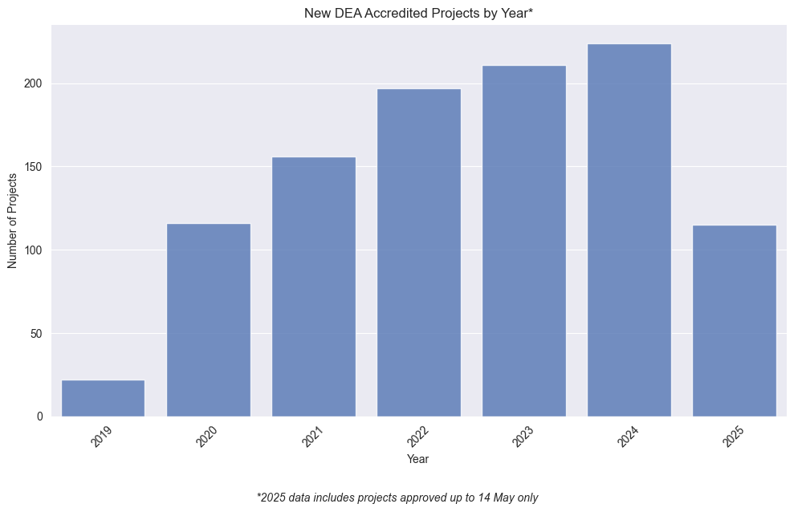

### Figure 2: Top 25 datasets accessed under the DEA between end 2019 - mid May 2025

| Rank | Dataset | # Count |
| --- | --- | --- |
| 1 | Business Structure Database | 220 |
| 2 | Annual Business Survey | 191 |
| 3 | Annual Survey of Hours and Earnings | 158 |
| 4 | Labour Force Survey | 151 |
| 5 | Annual Population Survey | 132 |
| 6 | Annual Respondents Database | 98 |
| 7 | Longitudinal Education Outcomes | 82 |
| 8 | UK Innovation Survey | 67 |
| 9 | Business Enterprise Research and Development | 54 |
| 10 | Understanding Society | 54 |
| 11 | Labour Force Survey Longitudinal | 37 |
| 12 | Business Register Employment Survey | 33 |
| 13 | Crime Survey for England and Wales | 31 |
| 14 | International Trade in Services | 29 |
| 15 | Labour Force Survey Household | 29 |
| 16 | Annual Survey of Hours and Earnings Longitudinal | 29 |
| 17 | Longitudinal Small Business Survey | 28 |
| 18 | ONS Longitudinal Study | 27 |
| 19 | Living Costs and Food Survey | 27 |
| 20 | Education and Child Health Insights from Linked Data | 25 |
| 21 | Growing Up in England | 23 |
| 22 | Wealth and Assets Survey | 21 |
| 23 | Data First: Crown Court Dataset | 20 |
| 24 | Longitudinal Study of England and Wales | 19 |
| 25 | Business Insights and Conditions Survey | 19 |

## Analysis of ADR UK flagship dataset demand

- Since Q1 2021 to end of Q1 2025, there have been 173 projects requesting access to a total of 218 ADR UK flagship datasets

### Figure 3: Growth in overall ADR England flagship data requests

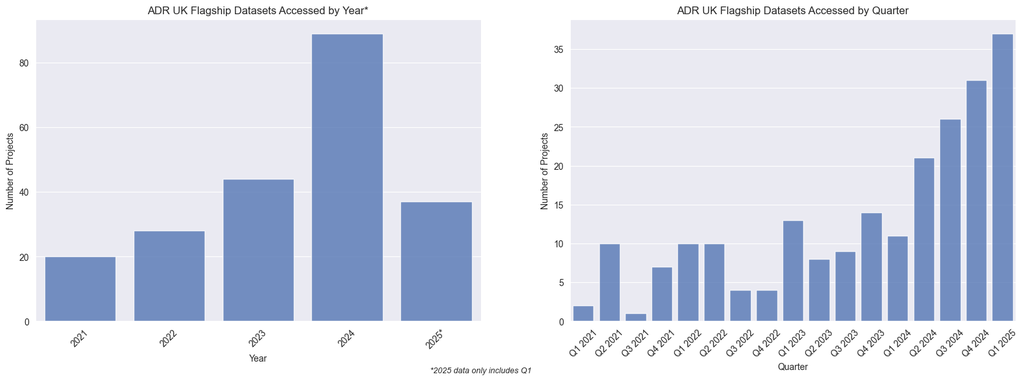

### Figure 4: Tables showing growth in overeall demand for ADR England flagship datasets

#### Annual Performance Summary

| Year | Annual Total | Avg per Quarter | Quarterly Std Dev | CV | Year-over-Year Growth |
| --- | --- | --- | --- | --- | --- |
| 2021 | 20 | 5.0 | 4.2 | 0.840 | — |
| 2022 | 28 | 7.0 | 3.5 | 0.500 | +40.0% |
| 2023 | 44 | 11.0 | 2.9 | 0.264 | +57.1% |
| 2024 | 89 | 22.2 | 8.5 | 0.383 | +102.3% |

#### Quarterly Breakdown

| Year | Q1 | Q2 | Q3 | Q4 | Annual Total |
| --- | --- | --- | --- | --- | --- |
| 2021 | 2 | 10 | 1 | 7 | 20 |
| 2022 | 10 | 10 | 4 | 4 | 28 |
| 2023 | 13 | 8 | 9 | 14 | 44 |
| 2024 | 11 | 21 | 26 | 31 | 89 |

#### Key Growth Metrics

| Metric | Value |
| --- | --- |
| **Compound Annual Growth Rate (2021-2024)** | **64.5%** |
| Total Growth | 345.0% |
| Average Annual Projects | 45 |

**Notes:**

- CV = Coefficient of Variation (volatility measure). Lower CV indicates more consistent quarterly performance

## Breakdowns by individual ADR UK flagship datatset collections

**Datasets included in WED collection**:

- Annual Survey of Hours and Earnings Longitudinal (I understand this was developed as part of WED)
- Annual Survey of Hours and Earnings Linked to Census 2011
- Annual Survey of Hours and Earnings Linked to PAYE and Self-Assessment Data

**Datasets included in Data First collection**:

- Data First: Crown Court Dataset
- Data First: Cross-Justice System Linking Dataset
- Data First: Prisoner Dataset
- Data First: Probation Dataset
- Data First: Family Court Dataset
- Data First: Magistrates Court Dataset
- Note: MoJ-DfE linkage is not included in this analysis

### Figure 4: Summary results table for individual collections

| Collection | Total | Avg Requests per Active Quarter | Coefficient of Variation | Avg Quarterly Growth Rate (%) | # Active Quarters |
| --- | --- | --- | --- | --- | --- |
| LEO | 80 | 5.0 | 0.97 | +98% | 16 |
| Data First | 49 | 3.1 | 1.13 | +95% | 16 |
| Wage and Employment Dynamics | 31 | 1.8 | 0.650 | +33% | 17 |
| ECHILD | 23 | 7.7 | 0.76 | +460% | 3 |
| Growing up in England | 21 | 1.5 | 1.19 | +38% | 14 |
| GRADE | 10 | 3.3 | 0.62 | -48% | 3 |
| Agricultural Research Collection | 4 | 0.4 | 1.85 | +50% | 11 |

TOP 3 BY TOTAL VOLUME:

1. LEO: 80 requests
2. Data First: 49 requests
3. Wage and Employment Dynamics: 31 requests

TOP 3 BY AVG QUARTERLY ACCESS REQUESTS:

1. ECHILD: 7.67 projects per quarter
2. LEO: 5.00 projects per quarter
3. GRADE: 3.33 projects per quarter

TOP 3 BY QUARTERLY GROWTH RATE:

1. ECHILD: +460.0% per quarter*
2. LEO: +97.6% per quarter
3. Data First: +94.9% per quarter

*The exceptionally high growth rate observed for ECHILD reflects its recent introduction, with access beginning only in the last three quarters - this short baseline inflates the calculated growth and should not be interpreted as a sustained long-term trend.

### Figure 5: Graphs showing total volume and average quarterly requests for each ADR England flagship dataset collection

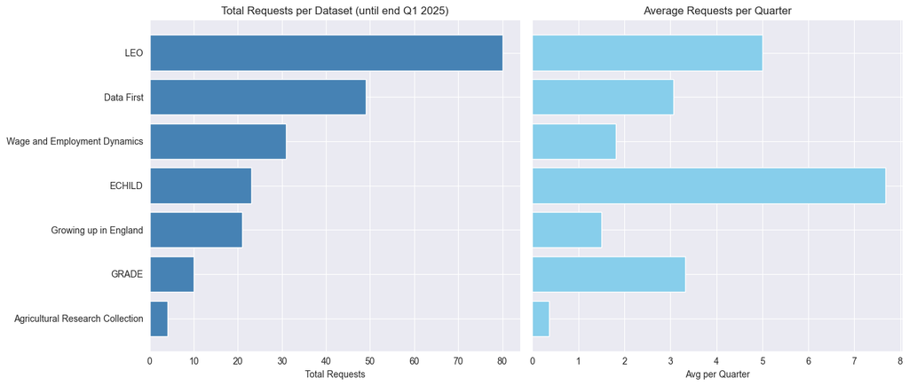

### Figure 6: Access requests for ADR England flagship datasets split by collection

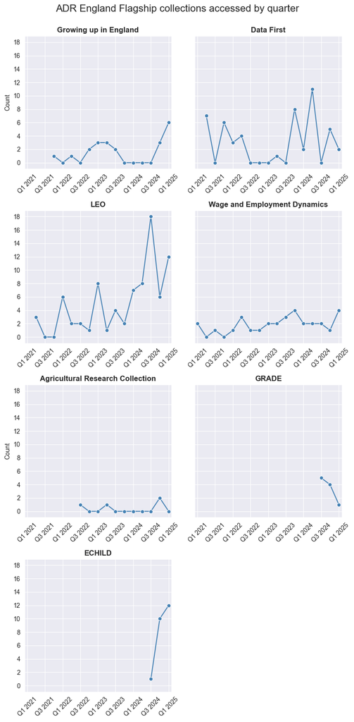

# Part 2: How have research topics and priorities evolved over time?

## Analysis of all DEA approved projects

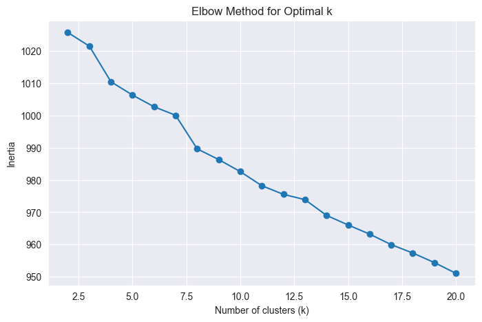

### Figure 7: Thematic clusters of DEA research project titles

This figure presents word clouds for four thematic clusters (Cluster 0, 1, and 2, 3) identified through KMeans clustering of TF-IDF vectorized project titles. Each cluster groups titles with similar keyword patterns. Word size reflects each term’s importance within the cluster, as measured by TF-IDF — capturing both frequency and uniqueness.

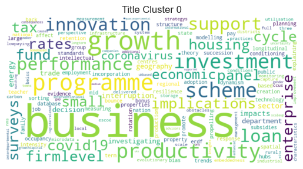

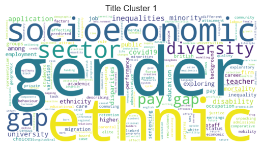

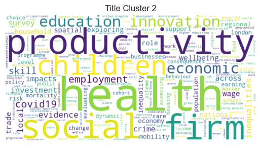

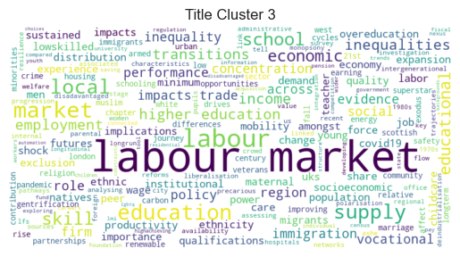

- Distinctive research terms across all DEA accredited project titles over the past 6 years can be split very broadly into four clusters:
  - Cluster 1: project titles on business, growth, and productivity;
  - Cluster 2: gender and ethnic inequalities and gaps,
  - Cluster 3: includes terms on health, social and children;
  - Cluster 4: labour market, skills and education terms.

### Figure 8: individual term trends for top 10 terms by year

Graphs track annual TF-IDF scores for ten most prominent research terms: labour, market, education, health, productivity, social, employment, covid19, economic, business; in project titles from the public register between 2020 and 2024. TF-IDF (Term Frequency–Inverse Document Frequency) reflects how important a term is in a specific year relative to other years, highlighting changes in salience over time. An upward trend indicates growing distinctiveness or emphasis of a term in that year's projects, while a decline suggests decreasing thematic prominence. Each panel shows the term’s yearly score, helping identify evolving research interests within the DEA-accredited landscape

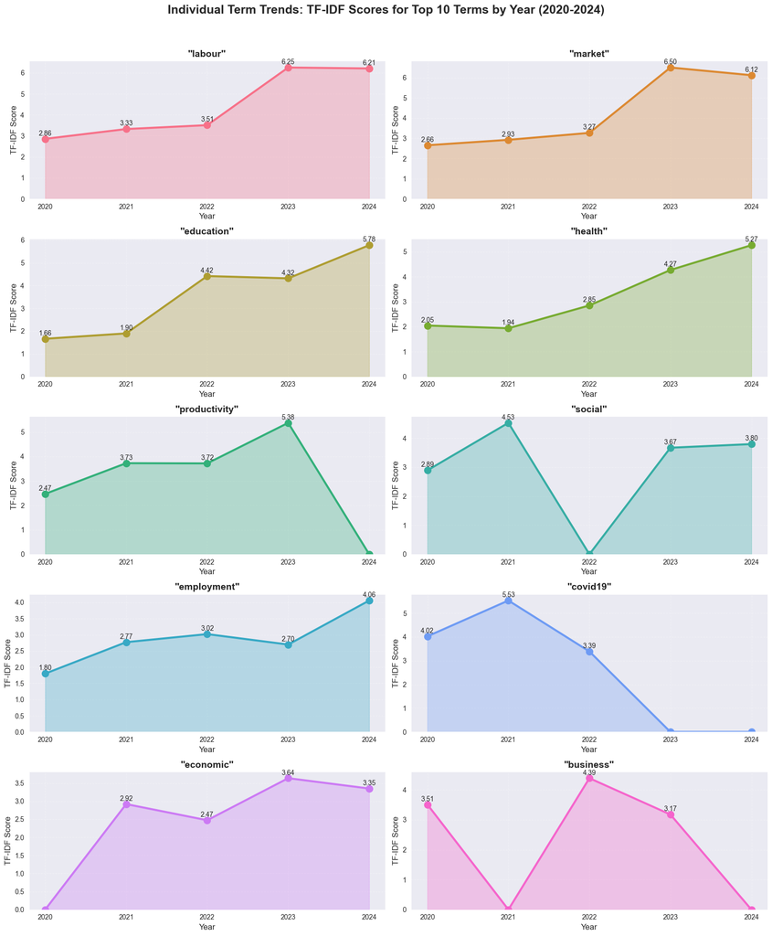

### Figure 9: Annual shifts in research emphasis (2020–2024): TF-IDF heatmap of top 10 terms in DEA project titles

This heatmap visualizes annual TF-IDF scores for the top 10 research terms found in project titles between 2020 and 2024. Each cell shows the TF-IDF score of a term in a given year, with warmer colors (orange to deep red) indicating higher relative importance of the term in that year’s corpus of titles. For example, covid19 peaked in importance in 2021 before disappearing in later years, while terms like education and labour grew more prominent over time. The color gradient helps highlight shifts in thematic focus across DEA-accredited research.

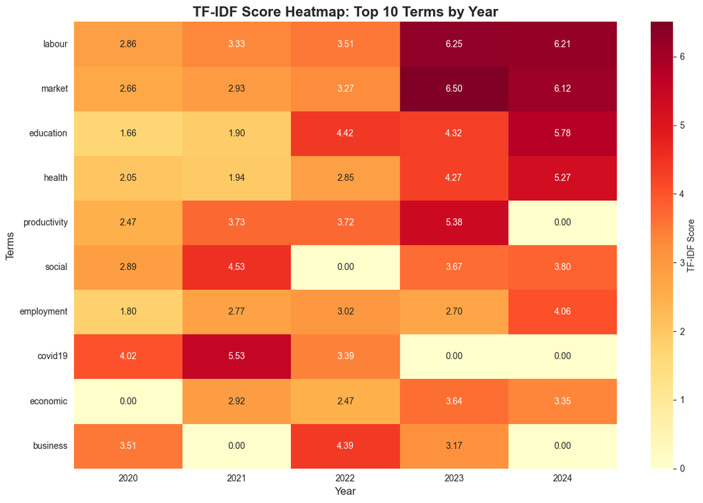

### Figure 10: Term usage trends in DEA Projects: Percentage of project titles mentioning top 10 terms

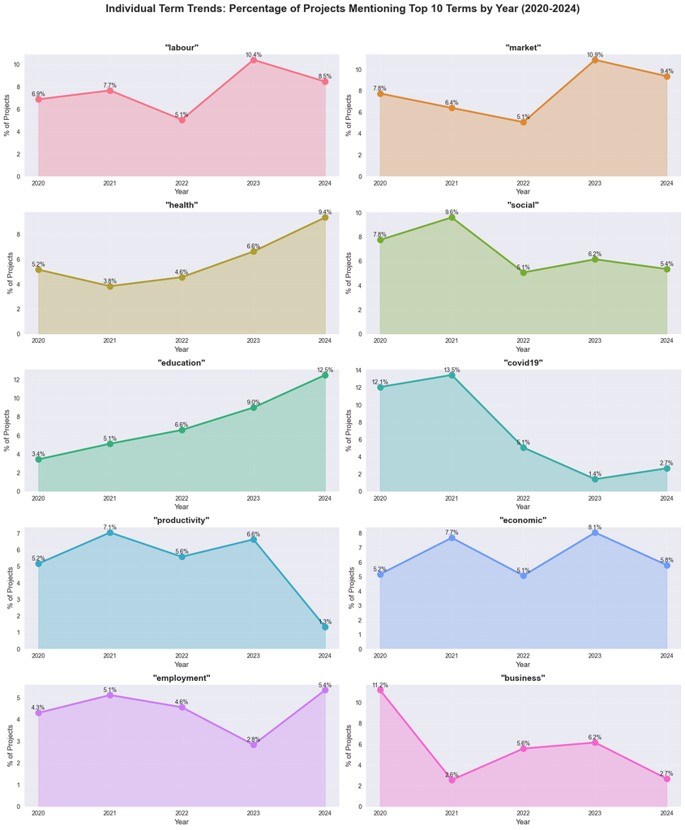

# Future possible directions

## Part 1: Dataset access trends

**Methodological improvements**:

- Fit a more complex model for growth in the use of different linked datasets to improve forecasts on future demand for flagship datasets and support better capacity plannning
  - Add significance test for growth trends
  - Cross-dataset synergies (network analysis of dataset combinations)
- incorporate flagship datasets from ADR UK partners in the devolved adminstrations
- Incorporate the popular MoJ-DfE linkage dataset into the Data First collection counts

**Additional questions**:

- Look at flagship dataset investment level to better understand the value for money in supporting different linkages in terms of their demand
- Develop the impact measurement with the addition of known research outputs (publications, policy briefs etc.) linked to approved project data
- User segmentation: what kind of research organsations (universities, government, third sector) are using these data? Are there centres of research activity using particular datasets?

**Other potential developments**

- Improve the transparency and accessibilty of the public register, providing a fully searchable and filterable web-based dataset for the public to better understand the research that is being undertaken using their data.
- Produce a web-based dashboard live-fed with data from the register to allow for automatically updated and easy-to-interpret visualisations of dataset use and research themes
- Produce an interactive dashboard where members of the public can enter basic personal details, and return the datasets (and therefore projects) that their data has been used in, providing a direct link between individuals' data and public benefit (espeically if these projects can be further linked to research outputs)

## Part 2: Topic trends in research

**Methodological improvements**

- N-gram analysis to find commonly co-occuring terms for a richer thematic analysis
- Clustering analysis using density-based approaches (e.g. DBSCAN) to improve cluster separation
- Dynamic topic modelling using gensim's Dynamic Topic Model or BERTopic for deeper analysis of changing trends

**Additional questions**

- How do topic trends align with government priorities?

**Other potential developments**

- Produce a recommendation system for researchers, suggesting relevant datasets based on their research questions

# Some limitations in this work

## Data collection and coverage limitations

- the public register only begins in Q4 2019, so early DEA usage and adoption trends since 2017 are not captured
- the public register only includes approved projects. We have no visibility into rejected applications, abandoned projects, or researchers discouraged by perceived barriers who never apply
- the focus on ADR England flagship datasets excludes those from Scotland, Wales, and Northern Ireland, limiting UK-wide insights;
- the MoJ-DfE linked dataset is omitted from Data First collection counts as it is not accessed via the DEA, potentially understating demand for justice-education data
- web scraping introduces risks of missed entries or parsing errors due to formatting changes which are not always easy to detect

## Technical and methodological constraints

- growth projection assumptions: exponential forecasts assume continued trends, but may be limited by funding, researcher capacity, processing delays, policy shifts, or demand saturation.
- title-based topic analysis: project titles may misrepresent research content, leading to misclassification, especially for generic or interdisciplinary studies.
- classification subjectivity: dataset grouping and thematic clustering involved subjective choices that may influence interpretation of trends.
- simple modeling approach: exponential models do not account for seasonality, structural breaks, capacity limits, or network effects across datasets.
- TF-IDF limitations: Lacks ability to detect semantic similarity or shifts in term meaning over time; more advanced NLP methods could yield different insights.
- statistical significance: this is a descriptive analysis only, no hypothesis testing was conducted to assess whether observed trends are statistically meaningful.

These limitations suggest findings should be treated as indicative rather than definitive. The dramatic growth rates observed may not be sustainable, and infrastructure planning should incorporate uncertainty ranges and scenario planning. Future work should address these limitations.